# Taller ggplot2 - Geoinquietos + RLadies Madrid

### Modificadores de apariencia

**Ejemplo final**: precio medio por distrito y tipo de habitación.

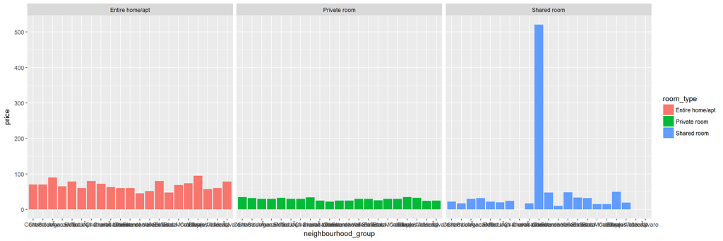

```r
ggplot(airbnb_listings, aes(x=neighbourhood_group, y=price, fill=room_type)) +
  stat_summary(fun.y=median, geom="bar") +
  facet_wrap(~ room_type, ncol=3)
```

Como la lista de distritos es larga, quedará mejor si ponemos las barras horizontales. Para eso usamos `coord_flip()`.

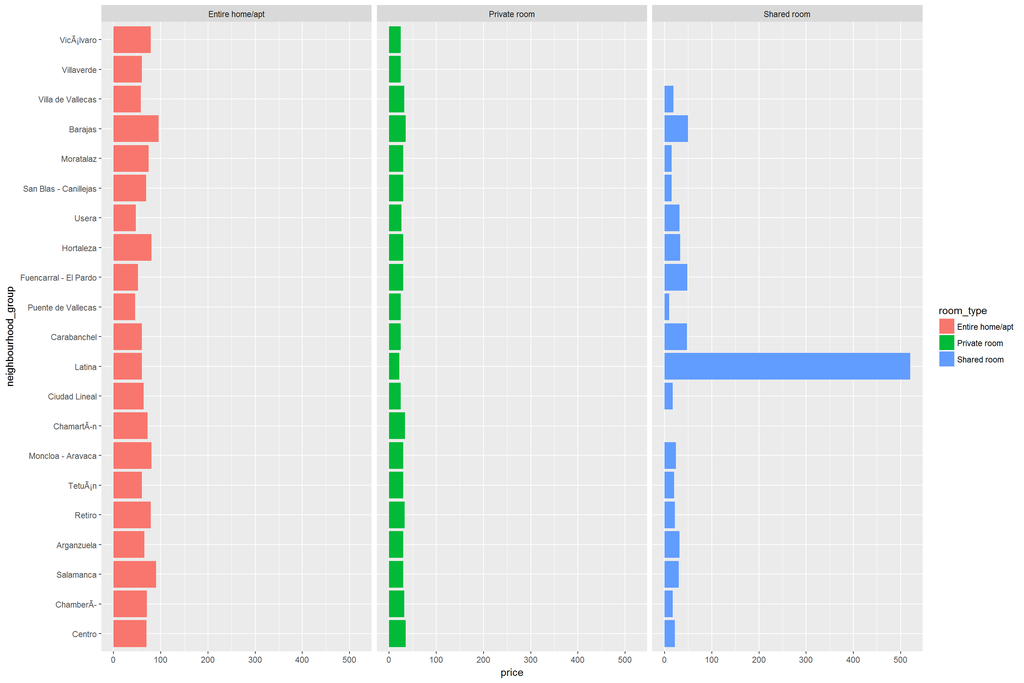

```r
ggplot(airbnb_listings, aes(x=neighbourhood_group, y=price, fill=room_type)) +
  stat_summary(fun.y=median, geom="bar") +
  facet_wrap(~ room_type, ncol=3) +
  coord_flip()
```

El outlier de La Latina hace que el resto de secciones no queden bien, porque comparten la escala del eje del precio. Podemos cambiar esto con el parámetro `scale` de `facet_wrap()`.

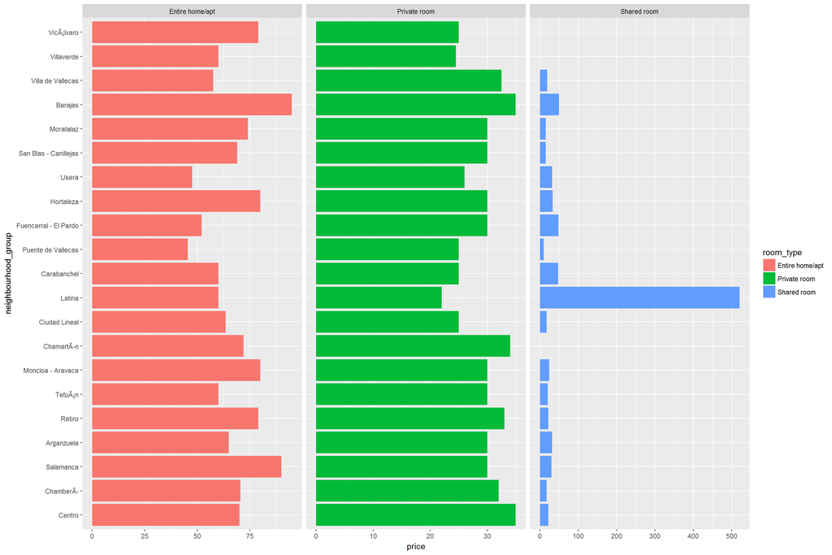

```r
ggplot(airbnb_listings, aes(x=neighbourhood_group, y=price, fill=room_type)) +
  stat_summary(fun.y=median, geom="bar") +
  facet_wrap(~ room_type, ncol=3, scale="free_x") +
  coord_flip()
```

Queremos meter también una etiqueta con el número de observaciones que entran en cada bloque. Para ello usamos `geom_text()` con el `stat` “count”. El parámetro hjust controla la posición relativa de las etiquetas (añade o quita margen).

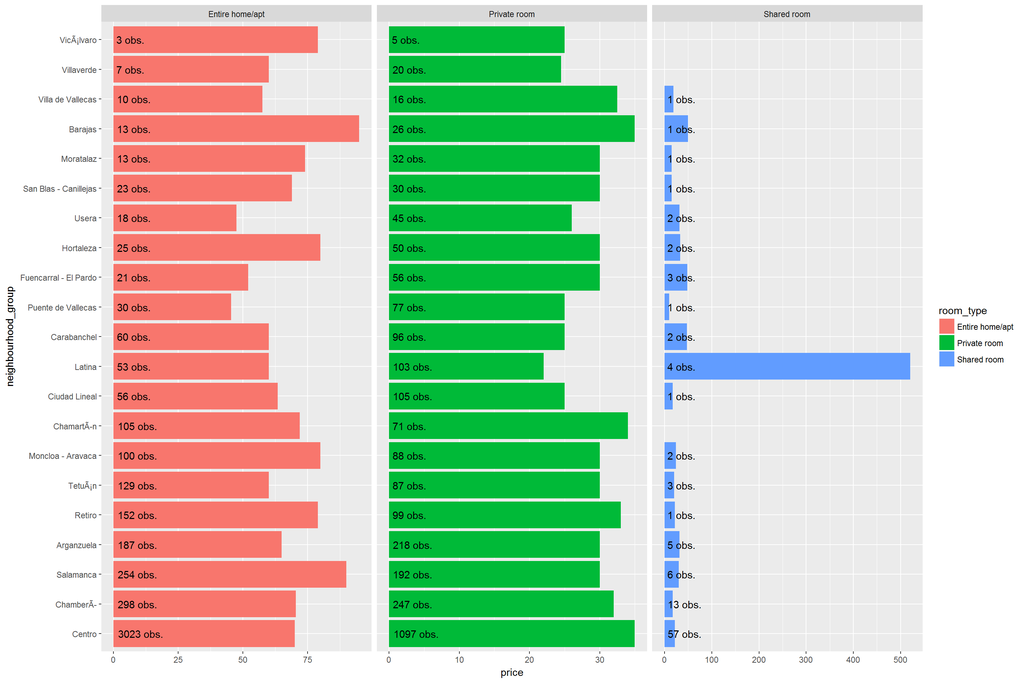

```r
ggplot(airbnb_listings, aes(x=neighbourhood_group, y=price, fill=room_type)) +
  stat_summary(fun.y=median, geom="bar") +
  geom_text(y=0, stat="count", aes(label=paste(..count.., "obs.")), hjust=-0.1) +
  facet_wrap(~ room_type, ncol=3, scale="free_x") +
  coord_flip()
```

Cosas que mejorar: - La leyenda con los colores no nos aporta nada porque ya tenemos los títulos en los bloques del facet. La podemos quitar usando la función `guides()`. - Para cambiar los nombres de los ejes y añadir un título podemos usar la función `labs()`.

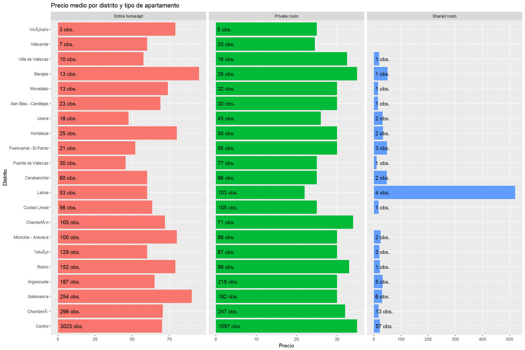

```r
ggplot(airbnb_listings, aes(x=neighbourhood_group, y=price, fill=room_type)) +
  stat_summary(fun.y=median, geom="bar") +
  geom_text(y=0, stat="count", aes(label=paste(..count.., "obs.")), hjust=-0.1) +
  facet_wrap(~ room_type, ncol=3, scale="free_x") +
  coord_flip() +
  guides(fill=FALSE) +
  labs(x="Distrito", y="Precio", title="Precio medio por distrito y tipo de apartamento")
```

Por defecto, los gráficos de ggplot2 salen con fondo gris y guías blancas. Eso (y otras muchas cosas como el tamaño de letra, el formato de las etiquetas, las leyendas, etc.) viene definido por el tema del gráfico. Para cambiarlo se usa la función `theme()`.

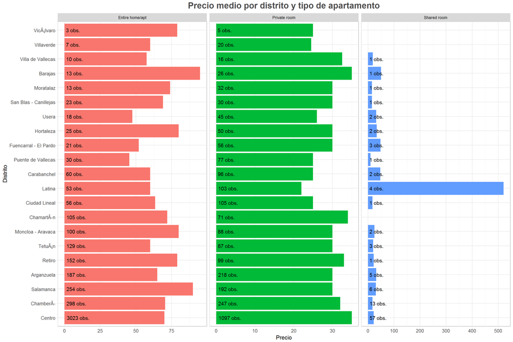

```r
ggplot(airbnb_listings, aes(x=neighbourhood_group, y=price, fill=room_type)) +
  stat_summary(fun.y=median, geom="bar") +
  geom_text(y=0, stat="count", aes(label=paste(..count.., "obs.")), hjust=-0.1) +
  facet_wrap(~ room_type, ncol=3, scale="free_x") +
  coord_flip() +
  guides(fill=FALSE) + labs(x="Distrito", y="Precio", title="Precio medio por distrito y tipo de apartamento") +
  theme(
    panel.background = element_rect(fill = "white", color="gray70"),
    panel.grid.major = element_line(colour = "gray90"),
    panel.grid.minor = element_line(colour = "gray95"),
    plot.title = element_text(size = 18, face = 'bold', colour = "gray30", hjust=0.5, vjust=1.5),
    axis.title.x = element_text(size = 12, vjust=-0.5),
    axis.title.y = element_text(size = 12, vjust=1),
    axis.text = element_text(size = 10),
    axis.ticks = element_line(colour = "gray90")
  )
```